# SAP projekt - Analiza podataka zdravstvenog pregleda

Ovisnost krvnog tlaka o pušenju

Testiramo postoji li statistički značajna razlika u prosječnim krvnim tlakovima kod pušača i kod nepušača. Pušenje je kategorijska varijabla (razlikujemo pušače i nepušače, a nema podataka o tome koliko često tko puši).

```r
library(nortest)
library(dplyr)
data = read.csv("Health Screening Data.csv")
names(data)
```

```
 [1] "X"           "id"          "age"         "gender"      "height"      "weight"      "ap_hi"       "ap_lo"       "cholesterol" "gluc"
[11] "smoke"       "alco"        "active"      "cardio"      "AgeinYr"     "BMI"         "BMICat"      "AgeGroup"
```

```r
summary(data)
```

```
       X               id             age            gender         height          weight           ap_hi            ap_lo           cholesterol
 Min.   :    0   Min.   :    0   Min.   :10798   Min.   :1.00   Min.   : 55.0   Min.   : 10.00   Min.   :-150.0   Min.   :  -70.00   Min.   :1.000
 1st Qu.:17497   1st Qu.:25002   1st Qu.:17665   1st Qu.:1.00   1st Qu.:159.0   1st Qu.: 65.00   1st Qu.: 120.0   1st Qu.:   80.00   1st Qu.:1.000
 Median :34995   Median :49994   Median :19703   Median :1.00   Median :165.0   Median : 72.00   Median : 120.0   Median :   80.00   Median :1.000
 Mean   :34998   Mean   :49970   Mean   :19469   Mean   :1.35   Mean   :164.4   Mean   : 74.21   Mean   : 126.7   Mean   :   96.65   Mean   :1.367
 3rd Qu.:52500   3rd Qu.:74890   3rd Qu.:21327   3rd Qu.:2.00   3rd Qu.:170.0   3rd Qu.: 82.00   3rd Qu.: 140.0   3rd Qu.:   90.00   3rd Qu.:2.000
 Max.   :69999   Max.   :99999   Max.   :23713   Max.   :2.00   Max.   :250.0   Max.   :200.00   Max.   : 240.0   Max.   :11000.00   Max.   :3.000
      gluc           smoke              alco             active           cardio          AgeinYr           BMI            BMICat
 Min.   :1.000   Min.   :0.00000   Min.   :0.00000   Min.   :0.0000   Min.   :0.0000   Min.   :29.00   Min.   :  3.50   Length:69960
 1st Qu.:1.000   1st Qu.:0.00000   1st Qu.:0.00000   1st Qu.:1.0000   1st Qu.:0.0000   1st Qu.:48.00   1st Qu.: 23.90   Class :character
 Median :1.000   Median :0.00000   Median :0.00000   Median :1.0000   Median :0.0000   Median :53.00   Median : 26.40   Mode  :character
 Mean   :1.226   Mean   :0.08818   Mean   :0.05377   Mean   :0.8037   Mean   :0.4996   Mean   :52.84   Mean   : 27.56
 3rd Qu.:1.000   3rd Qu.:0.00000   3rd Qu.:0.00000   3rd Qu.:1.0000   3rd Qu.:1.0000   3rd Qu.:58.00   3rd Qu.: 30.20
 Max.   :3.000   Max.   :1.00000   Max.   :1.00000   Max.   :1.0000   Max.   :1.0000   Max.   :64.00   Max.   :298.70
   AgeGroup
 Length:69960
 Class :character
 Mode  :character
```

Među podacima o krvnom tlaku ima besmislenih vrijednosti, poput negativnih brojeva ili jako niskih tlakova koji nisu fiziološki mogući.

```r
data$ap_hi[data$ap_hi < 30]
```

```
  [1]   14   14   11   12   14   11   14   12   14   12   10   16   12   14   12   12   12   11   12   12   12   12 -100   12   11    7   11   15   12
 [30]   17   16    1   13   12   15   11   12   12   11   14   12   12   12   12   14 -115   13   12   20   12   12   12   11   12   15   12 -100   12
 [59]   10   12   12   14   11 -140   12   12   15   13   20 -120   12   14   14   14   16   12   12   14   11   12   14   12   12   14   10   11   13
 [88]   12   12   11   20   11   11   14   12   11   12   12   11 -150   14   11   14   20   15   11   11   12   11   14   11   11   11    1   14   12
[117]   11   12   12   13   12   14   13   12 -120   12   12   14   12   13   14   12   11   12   11   12   13   12   12   13   15   24   14   13   12
[146]   15   12   12   12   13   12   17   10   14   17   12   10   12   12   14   15   15   15   12   15   13   12   10   12   12   12   13   12   11
[175]   12   13   10   14   11   12   15   12   12   12   14   14   12   13
```

Zato proglašavamo neispravnim i eliminiramo sve uzorke u kojima je zabilježen gornji (sistolički) tlak ispod 30 mmHg.

```r
ok = which(data$ap_hi >= 30)
data2 = data[ok,]
summary(data2$ap_hi)
```

```
   Min. 1st Qu.  Median    Mean 3rd Qu.    Max.
     60     120     120     127     140     240
```

Nakon filtriranja tlakove pušača i nepušača možemo prvo usporediti grafički pomoću box plotova. U uzorku preostaje oko 6100 pušača i 63000 nepušača nakon eliminacije besmislenih vrijednosti, što znači da imamo dovoljno podataka da kasnije u testiranju možemo koristiti centralni granični teorem. Vidimo da plotovi izgledaju dosta slično. I dalje postoji dosta outliera, pogotovo s visokim tlakom, ali nema ih smisla odbaciti kao pogrešna mjerenja jer je najveći tlak 240, što je sasvim moguća vrijednost.

```r
pusaci = data2[data2["smoke"]==1,]
nepusaci = data2[data2["smoke"]==0,]
nrow(pusaci)
```

```
[1] 6160
```

```r
nrow(nepusaci)
```

```
[1] 63612
```

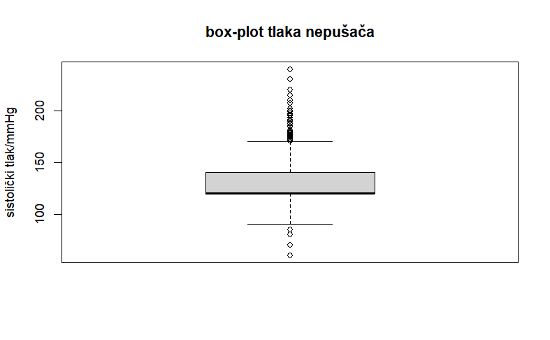

```r
boxplot(nepusaci$ap_hi,
        main='box-plot tlaka nepušača',
        ylab='sistolički tlak/mmHg')
```

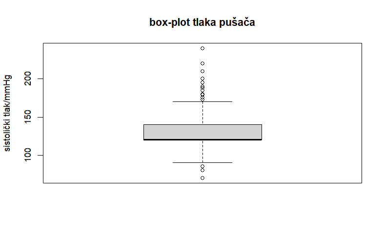

```r
boxplot(pusaci$ap_hi,
        main='box-plot tlaka pušača',
        ylab='sistolički tlak/mmHg')
```

Prikaz mjerenja sistoličkog tlaka na histogramu pokazuje da su vrijednosti često zaokruživane na najbliži “okrugli” broj. To može predstavljati problem u daljnem radu. Stoga ćemo na tlakove dodati aditivni uniformni šum s rasponom od -5 do 5. Odabrali smo uniformni šum jer nemamo nikakvu informaciju o originalnoj vrijednosti prije zaokruživanja osim da je morala biti iz navedenog raspona jer bi inače bila zaokružena na drugi broj. Nemamo razlog smatrati neku od vrijednosti iz tog raspona vjerojatnijom od drugih.

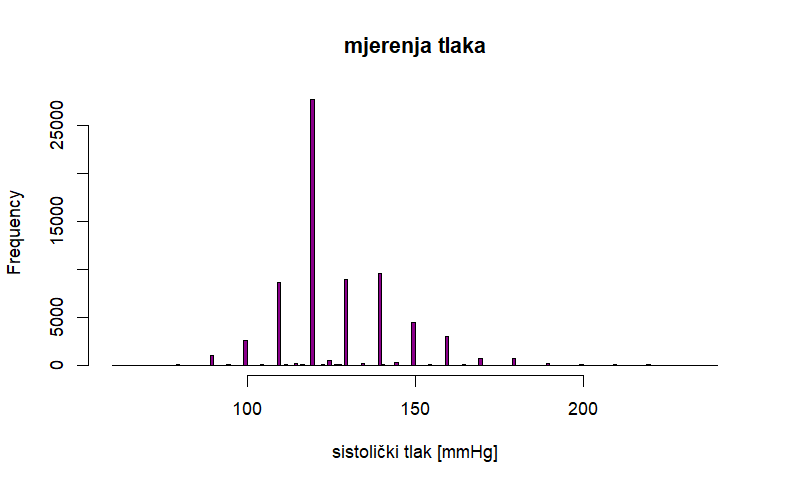

```r
hist(data2$ap_hi, breaks = seq(from=min(data2$ap_hi), to=max(data2$ap_hi), by=1), main="mjerenja tlaka",
xlab="sistolički tlak [mmHg]",
col="darkmagenta")
```

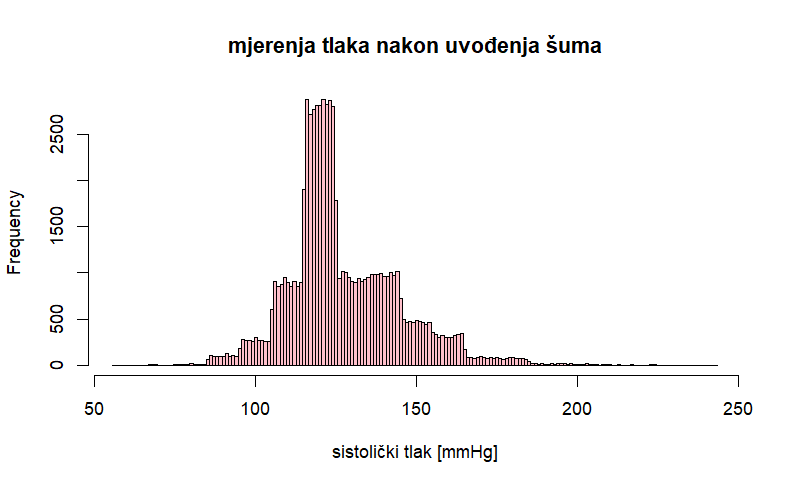

```r
set.seed(906)
data2 <- data2 %>%
  mutate(
    # ap_hi = (ap_hi + round(runif(n(), min=-5, max=4)*((ap_hi %% 10)==0))),
    # ap_lo = (ap_lo + round(runif(n(), min=-5, max=4)*((ap_lo %% 10)==0)))
    ap_hi = (ap_hi + runif(n(), min=-5, max=5)),
    ap_lo = (ap_lo + runif(n(), min=-5, max=5))

  )
hist(data2$ap_hi, breaks = seq(from=min(data2$ap_hi)-1, to=max(data2$ap_hi)+1, by=1), main="mjerenja tlaka nakon uvođenja šuma",
xlab="sistolički tlak [mmHg]",
col="pink")
```

Najprije provjeravama jesu li podaci iz normalne razdiobe. Kako ne znamo koju konkretnu normalnu razdiobu očekujemo, koristimo Lillieforsovu inačicu Kolmogorov-Smirnovljevog testa. Posebno testiramo tlakove pušača i tlakove nepušača. Također radimo Q-Q plotove za vizualnu usporedbu kvantila s kvantilima normalne razdiobe.

```r
pusaci = data2[data2["smoke"]==1,]
nepusaci = data2[data2["smoke"]==0,]

lillie.test(pusaci$ap_hi)
```

```
    Lilliefors (Kolmogorov-Smirnov) normality test

data:  pusaci$ap_hi
D = 0.10949, p-value < 2.2e-16
```

```r
lillie.test(nepusaci$ap_hi)
```

```
    Lilliefors (Kolmogorov-Smirnov) normality test

data:  nepusaci$ap_hi
D = 0.13341, p-value < 2.2e-16
```

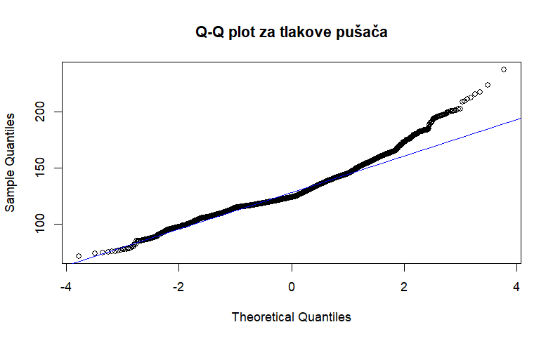

```r
qqnorm(pusaci$ap_hi, main = "Q-Q plot za tlakove pušača")
qqline(pusaci$ap_hi, col="blue")
```

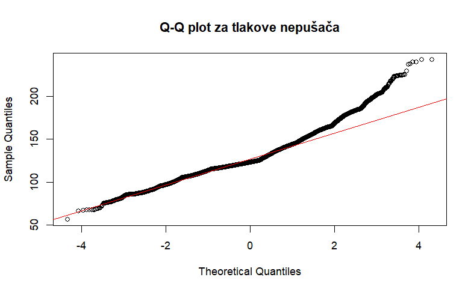

```r
qqnorm(nepusaci$ap_hi, main = "Q-Q plot za tlakove nepušača")
qqline(nepusaci$ap_hi, col="red")
```

Test odbacuje nul-hipotezu (da su podaci slučajan uzorak iz normalne razdiobe) za obje grupe na razini značajnosti od 1%. Na Q-Q plotovima vidimo da distribucija podataka relativno dobro prati normalnu za vrijednosti oko prosjeka i manje, ali ima vrlo teški rep prema većim vrijednostima. To je u skladu s prisutnošću mnogo outliera vidljivih u tom području na box plotu.

Treba provjeriti jesu li varijance grupa jednake. Provodimo F-test za jednakost varijanci sitoličkih tlakova nepušača i pušača. Dobivamo vrlo malu p-vrijednost, pa odbacujemo nul-hipotezu. Procijenjeni omjer varijanci je oko 0.9, dakle pušači imaju veću varijancu u sistoličkom tlaku nego nepušači. Poznato je da pušenje uzrokuje kratkotrajni porast krvnog tlaka. Moguće je tlakovi pušača više variraju jer su nekim pušačima tlakovi izmjereni ubrzo nakon pušenja, a nekima nakon nekoliko sati bez cigareta. U svakom slučaju, ne možemo pretpostaviti jednakost varijanci u daljnjim testovima.

```r
var.test(nepusaci$ap_hi, pusaci$ap_hi)
```

```
    F test to compare two variances

data:  nepusaci$ap_hi and pusaci$ap_hi
F = 0.90169, num df = 63611, denom df = 6159, p-value = 2.593e-08
alternative hypothesis: true ratio of variances is not equal to 1
95 percent confidence interval:
 0.8686983 0.9354055
sample estimates:
ratio of variances
         0.9016925
```

Testiramo hipotezu o jednakosti prosječnih krvnih tlakova u obje grupe koristeći T test za neuparene podatke uz nepoznate i nejednake varijance na razini značajnosti od 5%. Ne uzimamo pretpostavku da su varijance jednake zbog rezultata prethodnog testa.

```r
t.test(data2[data2["smoke"]==0,]$ap_hi, data2[data2["smoke"]==1,]$ap_hi, alternative = "two.sided", mu = 0, paired = FALSE, var.equal = FALSE, conf.level = 0.95)
```

```
    Welch Two Sample t-test

data:  data2[data2["smoke"] == 0, ]$ap_hi and data2[data2["smoke"] == 1, ]$ap_hi
t = -6.7088, df = 7276.2, p-value = 2.109e-11
alternative hypothesis: true difference in means is not equal to 0
95 percent confidence interval:
 -2.094059 -1.147027
sample estimates:
mean of x mean of y
 126.8500  128.4706
```

Dobivena P vrijednost je vrlo mala pa možemo odbaciti hipotezu o jednakosti srednjih vrijednosti sistoličkih tlakova na razini značajnosti od 5%. Test pokazuje statistički značajnu razliku, no procijenjena razlika sredina je mala u odnosu na 30 mmHg koliko otprilike iznosi širina intervala normalnih tlakova pa je značaj te razlike u praksi upitan.